# Stata’s `margins` command

Josh Errickson

2023-03-08

# Post-estimation command

- Stata “estimation” commands are primarily those which fit models.
  - E.g. `regress`, `logit`, `mixed`, `xtreg`.
- Stata “stores” the most recent estimation command.
- `margins` is a post-estimation command; meaning it will use the most recently run estimation.
- `margins` itself is *not* an estimation command.

# Categorical variables

```
. sysuse nlsw88
(NLSW, 1988 extract)

. list in 1

     +----------------------------------------------------------------+
  1. | idcode | age  |  race  | married  |    never_married  | grade  |
     |      1 |  37  | Black  |  Single  | Has been married  |    12  |
     |----------------------------------------------------------------|
     |          collgrad  |      south  |  smsa  |            c_city  |
     |  Not college grad  |  Not south  |  SMSA  |  Not central city  |
     |----------------------------------------------------------------|
     |               industry | occupation | union |     wage | hours |
     | Transport/Comm/Utility | Operatives | Union | 11.73913 |    48 |
     |----------------------------------------------------------------|
     |            ttl_exp            |              tenure            |
     |           10.33333            |            5.333333            |
     +----------------------------------------------------------------+
```

# Fitting the model

```
. regress wage i.race

      Source |       SS           df       MS      Number of obs   =     2,246
-------------+----------------------------------   F(2, 2243)      =     10.28
       Model |  675.510282         2  337.755141   Prob > F        =    0.0000
    Residual |  73692.4571     2,243  32.8544169   R-squared       =    0.0091
-------------+----------------------------------   Adj R-squared   =    0.0082
       Total |  74367.9674     2,245  33.1260434   Root MSE        =    5.7319

------------------------------------------------------------------------------
        wage | Coefficient  Std. err.      t    P>|t|     [95% conf. interval]
-------------+----------------------------------------------------------------
        race |
      Black  |  -1.238442   .2764488    -4.48   0.000    -1.780564   -.6963193
      Other  |   .4677818   1.133005     0.41   0.680    -1.754067    2.689631
             |
       _cons |   8.082999   .1416683    57.06   0.000     7.805185    8.360814
------------------------------------------------------------------------------
```

| Group | Average |  | Comparison | Diff. in Averages |
| --- | --- | --- | --- | --- |
| White | 8.083 |  | White vs Black | -1.238 |
| Black | ??? |  | White vs Other | 0.468 |
| Other | ??? |  | Black vs Other | ??? |

# Calculating group effects and comparisons

```
. regress, noheader
------------------------------------------------------------------------------
        wage | Coefficient  Std. err.      t    P>|t|     [95% conf. interval]
-------------+----------------------------------------------------------------
        race |
      Black  |  -1.238442   .2764488    -4.48   0.000    -1.780564   -.6963193
      Other  |   .4677818   1.133005     0.41   0.680    -1.754067    2.689631
             |
       _cons |   8.082999   .1416683    57.06   0.000     7.805185    8.360814
------------------------------------------------------------------------------
```

$$wage = \beta_0 + \beta_1\textrm{Black} + \beta_2\textrm{Other} +
\epsilon$$

| Group | Average |
| --- | --- |
| White | 8.083 |
| Black | 8.083 + -1.238 = 6.845 |
| Other | 8.083 + 0.468 = 8.551 |

| Comparison | Diff. in Averages |
| --- | --- |
| White vs Black | -1.238 |
| White vs Other | 0.468 |
| Black vs Other | 0.468 - -1.238 = 1.706 |

# Changing reference category

```
. regress wage ib2.race, noheader
------------------------------------------------------------------------------
        wage | Coefficient  Std. err.      t    P>|t|     [95% conf. interval]
-------------+----------------------------------------------------------------
        race |
      White  |   1.238442   .2764488     4.48   0.000     .6963193    1.780564
      Other  |   1.706223   1.148906     1.49   0.138    -.5468071    3.959254
             |
       _cons |   6.844558   .2373901    28.83   0.000     6.379031    7.310085
------------------------------------------------------------------------------

. regress wage ib3.race, noheader
------------------------------------------------------------------------------
        wage | Coefficient  Std. err.      t    P>|t|     [95% conf. interval]
-------------+----------------------------------------------------------------
        race |
      White  |  -.4677818   1.133005    -0.41   0.680    -2.689631    1.754067
      Black  |  -1.706223   1.148906    -1.49   0.138    -3.959254    .5468071
             |
       _cons |   8.550781   1.124114     7.61   0.000      6.34637    10.75519
------------------------------------------------------------------------------
```

# Estimated means

`margins` does this for us!

| Group | Average |
| --- | --- |
| White | 8.083 |
| Black | 8.083 + -1.238 = 6.845 |
| Other | 8.083 + 0.468 = 8.551 |

```
. margins race

Adjusted predictions                                     Number of obs = 2,246
Model VCE: OLS

Expression: Linear prediction, predict()

------------------------------------------------------------------------------
             |            Delta-method
             |     Margin   std. err.      t    P>|t|     [95% conf. interval]
-------------+----------------------------------------------------------------
        race |
      White  |   8.082999   .1416683    57.06   0.000     7.805185    8.360814
      Black  |   6.844558   .2373901    28.83   0.000     6.379031    7.310085
      Other  |   8.550781   1.124114     7.61   0.000      6.34637    10.75519
------------------------------------------------------------------------------
```

# Differences in estimated means

| Comparison | Diff. In Averages |
| --- | --- |
| White vs Black | -1.238 |
| White vs Other | 0.468 |
| Black vs Other | 0.468 - -1.238 = 1.706 |

```
. margins race, pwcompare

Pairwise comparisons of adjusted predictions             Number of obs = 2,246
Model VCE: OLS

Expression: Linear prediction, predict()

-----------------------------------------------------------------
                |            Delta-method         Unadjusted
                |   Contrast   std. err.     [95% conf. interval]
----------------+------------------------------------------------
           race |
Black vs White  |  -1.238442   .2764488     -1.780564   -.6963193
Other vs White  |   .4677818   1.133005     -1.754067    2.689631
Other vs Black  |   1.706223   1.148906     -.5468071    3.959254
-----------------------------------------------------------------
```

# Syntax for estimated means

Average outcome per level

```
margins [categorical variable]
```

Pairwise comparisons between groups

```
margins [categorical variable], pwcompare(ci) // Produce confidence intervals, default
margins [categorical variable], pwcompare(pv) // Produce p-values
```

- Do not preface the categorical variable with `i.`.
- In general, binary (0/1) variables can be treated as continuous or categorical in the model. The model is identical either way, but treating them as categorical lets `margins` operate in this easy fashion.

# In the presence of covariates

```
. regress wage age i.married, noheader
------------------------------------------------------------------------------
        wage | Coefficient  Std. err.      t    P>|t|     [95% conf. interval]
-------------+----------------------------------------------------------------
         age |  -.0692705   .0396596    -1.75   0.081     -.147044    .0085029
             |
     married |
    Married  |  -.4958806   .2530888    -1.96   0.050    -.9921934    .0004321
       _cons |   10.79748   1.568569     6.88   0.000     7.721481    13.87348
------------------------------------------------------------------------------
```

```
. margins married

Predictive margins                                       Number of obs = 2,246
Model VCE: OLS

Expression: Linear prediction, predict()

------------------------------------------------------------------------------
             |            Delta-method
             |     Margin   std. err.      t    P>|t|     [95% conf. interval]
-------------+----------------------------------------------------------------
     married |
     Single  |   8.085319   .2027826    39.87   0.000     7.687658    8.482981
    Married  |   7.589439    .151412    50.12   0.000     7.292517    7.886361
------------------------------------------------------------------------------
```

# Visualization of `margins`

```
margins married
```

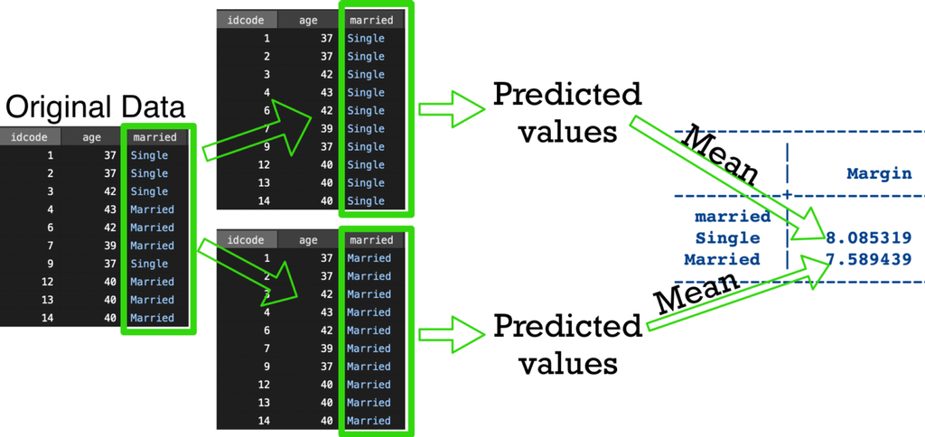

Sometimes called “as observed”.

# Choices for ways to handle other covariates

1. As observed (default)
   - Average of predicted outcomes
2. `atmeans`
   - Predicted outcome at average
3. `at` specific values
   - Predicted outcome at specific values
4. Combination (if multiple covariates)

# Visualization of `margins, atmeans`

```
margins married, atmeans
```

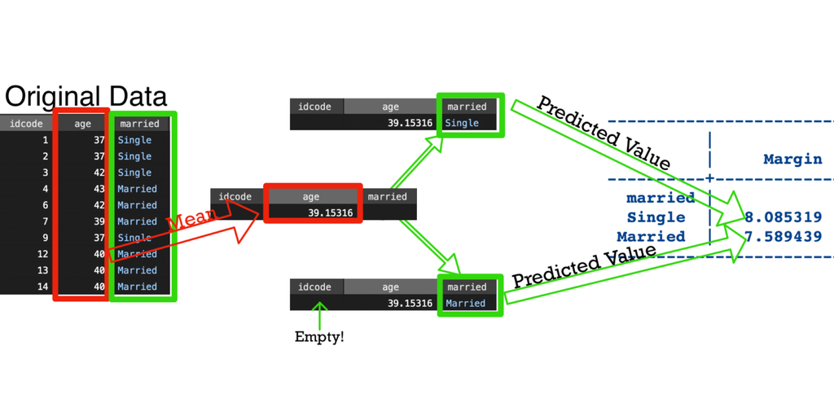

# `atmeans`

```
. margins married, atmeans

Adjusted predictions                                     Number of obs = 2,246
Model VCE: OLS

Expression: Linear prediction, predict()
At: age       = 39.15316 (mean)
    0.married = .3579697 (mean)
    1.married = .6420303 (mean)

------------------------------------------------------------------------------
             |            Delta-method
             |     Margin   std. err.      t    P>|t|     [95% conf. interval]
-------------+----------------------------------------------------------------
     married |
     Single  |   8.085319   .2027826    39.87   0.000     7.687658    8.482981
    Married  |   7.589439    .151412    50.12   0.000     7.292517    7.886361
------------------------------------------------------------------------------
```

- Means for `married` are ignored since we’re requesting at specific values of `married`.
- As observed and `atmeans` are identical for linear models; but differ for generalized linear models (we’ll see later).

# `at` specific values

We can manually fix the values of other variables in the model.

```
margins, at(<variable> = (<numlist>) <variable2> = (<numlist>))
```

where `<numlist>` can be any of:

- space-separated list of values (`3 4 .5 -100`)
- integers between range (`2/5` is equivalent to `2 3 4 5`)
- range with step-by instruction (`3(.5)5` is equivalent to `3 3.5 4 4.5 5`)
- any combination of the above (`3 5/7 8(.25)9`)

# `at` specific values example

```
. margins married, at(age = (35(5)45))

Adjusted predictions                                     Number of obs = 2,246
Model VCE: OLS

Expression: Linear prediction, predict()
1._at: age = 35
2._at: age = 40
3._at: age = 45

------------------------------------------------------------------------------
             |            Delta-method
             |     Margin   std. err.      t    P>|t|     [95% conf. interval]
-------------+----------------------------------------------------------------
 _at#married |
   1#Single  |   8.373011   .2628879    31.85   0.000     7.857482     8.88854
  1#Married  |    7.87713   .2226589    35.38   0.000     7.440491     8.31377
   2#Single  |   8.026658   .2051185    39.13   0.000     7.624416      8.4289
  2#Married  |   7.530778   .1554066    48.46   0.000     7.226022    7.835534
   3#Single  |   7.680306   .3060744    25.09   0.000     7.080087    8.280524
  3#Married  |   7.184425   .2781542    25.83   0.000     6.638959    7.729892
------------------------------------------------------------------------------
```

# Visualization of `margins, at(...)`

```
margins married, at(age = (35(5)45))
```

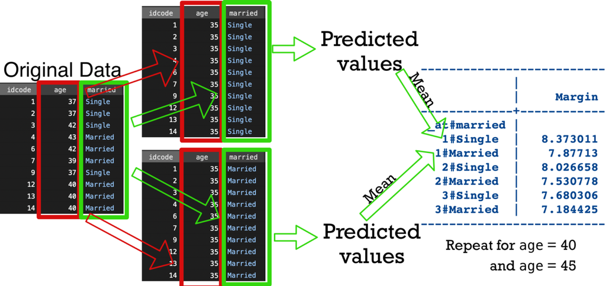

# `at` without categorical variables

We can also use `at` with continuous variables without a categorical variable.

```
. margins, at(age = (35(5)45))

Predictive margins                                       Number of obs = 2,246
Model VCE: OLS

Expression: Linear prediction, predict()
1._at: age = 35
2._at: age = 40
3._at: age = 45

------------------------------------------------------------------------------
             |            Delta-method
             |     Margin   std. err.      t    P>|t|     [95% conf. interval]
-------------+----------------------------------------------------------------
         _at |
          1  |   8.054641   .2045676    39.37   0.000     7.653479    8.455802
          2  |   7.708288    .125879    61.24   0.000     7.461436     7.95514
          3  |   7.361935   .2617012    28.13   0.000     6.848734    7.875137
------------------------------------------------------------------------------
```

# Combining these effects

We can combine “as observed”/`atmeans` and `at` when we have multiple predictors.

```
. regress wage age i.married i.south, noheader
------------------------------------------------------------------------------
        wage | Coefficient  Std. err.      t    P>|t|     [95% conf. interval]
-------------+----------------------------------------------------------------
         age |  -.0675817   .0393325    -1.72   0.086    -.1447135    .0095502
             |
     married |
    Married  |  -.5039005   .2509983    -2.01   0.045    -.9961138   -.0116873
             |
       south |
      South  |  -1.514432   .2438214    -6.21   0.000    -1.992572   -1.036293
       _cons |   11.37168   1.558336     7.30   0.000     8.315744    14.42761
------------------------------------------------------------------------------
```

# Combining these effects, 2

```
regress wage age i.married i.south
```

```
. margins married, at(south = (1)) atmeans

Adjusted predictions                                     Number of obs = 2,246
Model VCE: OLS

Expression: Linear prediction, predict()
At: age       = 39.15316 (mean)
    0.married = .3579697 (mean)
    1.married = .6420303 (mean)
    south     =        1

------------------------------------------------------------------------------
             |            Delta-method
             |     Margin   std. err.      t    P>|t|     [95% conf. interval]
-------------+----------------------------------------------------------------
     married |
     Single  |   7.211208   .2454553    29.38   0.000     6.729864    7.692551
    Married  |   6.707307   .2066834    32.45   0.000     6.301996    7.112618
------------------------------------------------------------------------------
```

- Note the use of a categorical variable (`south`) in `at()`.
- Recall that `married`’s means are ignored.

# Estimated slopes

Everything we’ve done so far is estimating means. We can estimate slopes with the `dydx` option.

```
. regress wage age, noheader
------------------------------------------------------------------------------
        wage | Coefficient  Std. err.      t    P>|t|     [95% conf. interval]
-------------+----------------------------------------------------------------
         age |  -.0680236   .0396796    -1.71   0.087    -.1458362     .009789
       _cons |   10.43029   1.558318     6.69   0.000     7.374394    13.48618
------------------------------------------------------------------------------

. margins, dydx(age)

Average marginal effects                                 Number of obs = 2,246
Model VCE: OLS

Expression: Linear prediction, predict()
dy/dx wrt:  age

------------------------------------------------------------------------------
             |            Delta-method
             |      dy/dx   std. err.      t    P>|t|     [95% conf. interval]
-------------+----------------------------------------------------------------
         age |  -.0680236   .0396796    -1.71   0.087    -.1458362     .009789
------------------------------------------------------------------------------
```

# Non-linear relationships

```
. regress wage c.age##c.age, noheader
------------------------------------------------------------------------------
        wage | Coefficient  Std. err.      t    P>|t|     [95% conf. interval]
-------------+----------------------------------------------------------------
         age |   .7033681   1.084471     0.65   0.517    -1.423304     2.83004
             |
 c.age#c.age |  -.0097745   .0137323    -0.71   0.477    -.0367039     .017155
             |
       _cons |  -4.696709   21.30931    -0.22   0.826    -46.48474    37.09133
------------------------------------------------------------------------------

. margins, dydx(age)

Average marginal effects                                 Number of obs = 2,246
Model VCE: OLS

Expression: Linear prediction, predict()
dy/dx wrt:  age

------------------------------------------------------------------------------
             |            Delta-method
             |      dy/dx   std. err.      t    P>|t|     [95% conf. interval]
-------------+----------------------------------------------------------------
         age |  -.0620333   .0405666    -1.53   0.126    -.1415852    .0175186
------------------------------------------------------------------------------
```

# Estimated marginal slopes, comments

- This will get a lot more useful when we discuss interactions next.
- Handling additional covariates with “as observed”/`atmeans` or `at` continues to work.
- In linear models, “average slope” and “slope at average” are equivalent - not true in non-linear models.
- There are additional options such as `eyex` for “elasticities”, an extremely similar concept in econometrics.

# Instantenous slopes

For non-linear trends, the slope changes across values of the predictor.

[figure not shown]

(This is also the **tangent**, and is obtained by taking the derivative, which is often written as $\frac{dy}{dx}$, hence the option `dydx`.)

# Estimating the instantenous slope

```
regress wage c.age##c.age
```

```
. margins, dydx(age) at(age = (35 40 45))

Conditional marginal effects                             Number of obs = 2,246
Model VCE: OLS

Expression: Linear prediction, predict()
dy/dx wrt:  age
1._at: age = 35
2._at: age = 40
3._at: age = 45

------------------------------------------------------------------------------
             |            Delta-method
             |      dy/dx   std. err.      t    P>|t|     [95% conf. interval]
-------------+----------------------------------------------------------------
age          |
         _at |
          1  |   .0191564   .1287496     0.15   0.882    -.2333243    .2716372
          2  |  -.0785881   .0423687    -1.85   0.064    -.1616741     .004498
          3  |  -.1763326   .1572552    -1.12   0.262    -.4847135    .1320483
------------------------------------------------------------------------------
```

# Examining interactions

Recall our starting example with a categorical variable and the regression coefficients only telling part of the story.

```
regress wage i.race
```

| Group | Average |  | Comparison | Estimate |
| --- | --- | --- | --- | --- |
| White | 8.083 |  | White vs Black | -1.238 |
| Black | ??? |  | White vs Other | 0.468 |
| Other | ??? |  | Black vs Other | ??? |

We only get 50% of relevant pieces of information from the regression coefficients.

When we begin to include interactions in the model, even less useful information can be extracted via regression coefficients alone.

# Categorical-categorical interaction

```
. regress wage i.married##i.race, noheader
------------------------------------------------------------------------------
        wage | Coefficient  Std. err.      t    P>|t|     [95% conf. interval]
-------------+----------------------------------------------------------------
     married |
    Married  |  -1.204674    .309034    -3.90   0.000    -1.810697   -.5986511
             |
        race |
      Black  |  -2.194947    .415727    -5.28   0.000    -3.010198   -1.379697
      Other  |  -.4967496   2.037457    -0.24   0.807    -4.492251    3.498752
             |
married#race |
    Married #|
      Black  |   1.439186   .5661142     2.54   0.011     .3290224    2.549349
    Married #|
      Other  |   1.375469   2.448432     0.56   0.574    -3.425963    6.176901
             |
       _cons |   8.929288   .2590186    34.47   0.000     8.421347     9.43723
------------------------------------------------------------------------------
```

$3\times2 = 6$ total subgroups, $\binom{6}{2} = 15$ different pairwise comparisons.

# `margins` syntax with interactions

- Average of each level of `married`, averaged across `race`:

  ```
  margins married
  ```

- Average of each unique subgroup of `married` and `race`:

  ```
  margins married#race
  ```

  (Note the single `#` instead of the `##` in the model.)
- Pairwise differences between all unique subgroups:

  ```
  margins married#race, pwcompare(ci) // default
  margins married#race, pwcompare(pv)
  ```

- Average effect of `marriage` within levels of `race`:

  ```
  margins married@race, contrast(ci nowald)
  margins married@race, contrast(pv nowald)
  ```

# Marginal effects

```
. margins married

Predictive margins                                       Number of obs = 2,246
Model VCE: OLS

Expression: Linear prediction, predict()

------------------------------------------------------------------------------
             |            Delta-method
             |     Margin   std. err.      t    P>|t|     [95% conf. interval]
-------------+----------------------------------------------------------------
     married |
     Single  |    8.35379   .2081151    40.14   0.000     7.945671    8.761909
    Married  |   7.538612   .1528743    49.31   0.000     7.238821    7.838402
------------------------------------------------------------------------------
```

# Estimated means in all unique subgroups

```
. margins married#race

Adjusted predictions                                     Number of obs = 2,246
Model VCE: OLS

Expression: Linear prediction, predict()

------------------------------------------------------------------------------
             |            Delta-method
             |     Margin   std. err.      t    P>|t|     [95% conf. interval]
-------------+----------------------------------------------------------------
married#race |
     Single #|
      White  |   8.929288   .2590186    34.47   0.000     8.421347     9.43723
     Single #|
      Black  |   6.734341   .3251742    20.71   0.000     6.096667    7.372016
     Single #|
      Other  |   8.432539   2.020926     4.17   0.000     4.469456    12.39562
    Married #|
      White  |   7.724614   .1685569    45.83   0.000      7.39407    8.055158
    Married #|
      Black  |   6.968853   .3453187    20.18   0.000     6.291675    7.646031
    Married #|
      Other  |   8.603333   1.347284     6.39   0.000     5.961278    11.24539
------------------------------------------------------------------------------
```

# All pairwise comparisons

```
. margins married#race, pwcompare(pv)

Pairwise comparisons of adjusted predictions             Number of obs = 2,246
Model VCE: OLS

Expression: Linear prediction, predict()

----------------------------------------------------------------------------
                                    |            Delta-method    Unadjusted
                                    |   Contrast   std. err.      t    P>|t|
------------------------------------+---------------------------------------
                       married#race |
  (Single#Black) vs (Single#White)  |  -2.194947    .415727    -5.28   0.000
  (Single#Other) vs (Single#White)  |  -.4967496   2.037457    -0.24   0.807
 (Married#White) vs (Single#White)  |  -1.204674    .309034    -3.90   0.000
 (Married#Black) vs (Single#White)  |  -1.960435   .4316661    -4.54   0.000
 (Married#Other) vs (Single#White)  |  -.3259551   1.371956    -0.24   0.812
  (Single#Other) vs (Single#Black)  |   1.698198    2.04692     0.83   0.407
 (Married#White) vs (Single#Black)  |   .9902731   .3662645     2.70   0.007
 (Married#Black) vs (Single#Black)  |   .2345117    .474324     0.49   0.621
 (Married#Other) vs (Single#Black)  |   1.868992    1.38597     1.35   0.178
 (Married#White) vs (Single#Other)  |  -.7079245   2.027943    -0.35   0.727
 (Married#Black) vs (Single#Other)  |  -1.463686   2.050216    -0.71   0.475
 (Married#Other) vs (Single#Other)  |   .1707945   2.428851     0.07   0.944
(Married#Black) vs (Married#White)  |  -.7557614   .3842609    -1.97   0.049
(Married#Other) vs (Married#White)  |    .878719   1.357787     0.65   0.518
(Married#Other) vs (Married#Black)  |    1.63448   1.390834     1.18   0.240
----------------------------------------------------------------------------
```

# Effect of `married` within each `race`

```
. margins married@race, contrast(pv nowald)

Contrasts of adjusted predictions                        Number of obs = 2,246
Model VCE: OLS

Expression: Linear prediction, predict()

-----------------------------------------------------------------
                         |            Delta-method
                         |   Contrast   std. err.      t    P>|t|
-------------------------+---------------------------------------
            married@race |
(Married vs base) White  |  -1.204674    .309034    -3.90   0.000
(Married vs base) Black  |   .2345117    .474324     0.49   0.621
(Married vs base) Other  |   .1707945   2.428851     0.07   0.944
-----------------------------------------------------------------
```

Note the use of `@` rather than `#`.

# `contrast` options

We can run just `margins married@race` without a `contrast` argument but it will only produce a Wald test table. Switching `married@race` to `race@married`:

```
. margins race@married

Contrasts of adjusted predictions                        Number of obs = 2,246
Model VCE: OLS

Expression: Linear prediction, predict()

------------------------------------------------
             |         df           F        P>F
-------------+----------------------------------
race@married |
     Single  |          2       13.95     0.0000
    Married  |          2        2.22     0.1089
      Joint  |          4        8.09     0.0000
             |
 Denominator |       2240
------------------------------------------------
```

`nowald` option to `contrast` suppresses this table; `pv` or `ci` produce the estimate table. (So `contrast(ci)` would produce both tables.)

# Effect of `race` within each `married`

```
. margins race@married, contrast(pv nowald)

Contrasts of adjusted predictions                        Number of obs = 2,246
Model VCE: OLS

Expression: Linear prediction, predict()

-----------------------------------------------------------------
                         |            Delta-method
                         |   Contrast   std. err.      t    P>|t|
-------------------------+---------------------------------------
            race@married |
 (Black vs base) Single  |  -2.194947    .415727    -5.28   0.000
(Black vs base) Married  |  -.7557614   .3842609    -1.97   0.049
 (Other vs base) Single  |  -.4967496   2.037457    -0.24   0.807
(Other vs base) Married  |    .878719   1.357787     0.65   0.518
-----------------------------------------------------------------
```

Since `race` has more than 2 categories, each comparison is against a reference category. This isn’t a problem if the first variable in the `margins` call is binary, but is annoying otherwise.

# Displaying all pairwise comparisons within `married` status

```
. margins race, at(married = (0)) pwcompare(pv)

Pairwise comparisons of adjusted predictions             Number of obs = 2,246
Model VCE: OLS

Expression: Linear prediction, predict()
At: married = 0

--------------------------------------------------------
                |            Delta-method    Unadjusted
                |   Contrast   std. err.      t    P>|t|
----------------+---------------------------------------
           race |
Black vs White  |  -2.194947    .415727    -5.28   0.000
Other vs White  |  -.4967496   2.037457    -0.24   0.807
Other vs Black  |   1.698198    2.04692     0.83   0.407
--------------------------------------------------------
```

Repeat for `married = (1)`

# Categorical-continuous interactions

```
. regress wage c.age##i.race, noheader
------------------------------------------------------------------------------
        wage | Coefficient  Std. err.      t    P>|t|     [95% conf. interval]
-------------+----------------------------------------------------------------
         age |  -.0545975   .0459913    -1.19   0.235    -.1447876    .0355926
             |
        race |
      Black  |   1.403328   3.590285     0.39   0.696    -5.637306    8.443963
      Other  |   27.42823   14.02561     1.96   0.051    -.0763282    54.93278
             |
  race#c.age |
      Black  |  -.0687157   .0919576    -0.75   0.455    -.2490468    .1116154
      Other  |  -.6858332   .3556579    -1.93   0.054    -1.383287    .0116202
             |
       _cons |   10.22718   1.811727     5.64   0.000     6.674339    13.78002
------------------------------------------------------------------------------
```

| Group | Slope |  | Comparison | Diff. in slopes |
| --- | --- | --- | --- | --- |
| White | -0.055 |  | White vs Black | -0.069 |
| Black | ??? |  | White vs Other | -0.686 |
| Other | ??? |  | Black vs Other | ??? |

# Estimating marginal slopes in each `race`

```
. margins race, dydx(age)

Average marginal effects                                 Number of obs = 2,246
Model VCE: OLS

Expression: Linear prediction, predict()
dy/dx wrt:  age

------------------------------------------------------------------------------
             |            Delta-method
             |      dy/dx   std. err.      t    P>|t|     [95% conf. interval]
-------------+----------------------------------------------------------------
age          |
        race |
      White  |  -.0545975   .0459913    -1.19   0.235    -.1447876    .0355926
      Black  |  -.1233132   .0796304    -1.55   0.122    -.2794703    .0328439
      Other  |  -.7404307   .3526717    -2.10   0.036    -1.432028   -.0488332
------------------------------------------------------------------------------
```

# Testing for differences between marginal slopes

```
. margins race, dydx(age) pwcompare(pv)

Pairwise comparisons of average marginal effects

Model VCE: OLS                                           Number of obs = 2,246

Expression: Linear prediction, predict()
dy/dx wrt:  age

--------------------------------------------------------
                |   Contrast Delta-method    Unadjusted
                |      dy/dx   std. err.      t    P>|t|
----------------+---------------------------------------
age             |
           race |
Black vs White  |  -.0687157   .0919576    -0.75   0.455
Other vs White  |  -.6858332   .3556579    -1.93   0.054
Other vs Black  |  -.6171175   .3615499    -1.71   0.088
--------------------------------------------------------
```

# Looking at it the other way

Prior was “Differences in effect of age across race”. Now looking at “differences in races across values of age”:

```
. margins race, at(age = (35 45))

Adjusted predictions                                     Number of obs = 2,246
Model VCE: OLS

Expression: Linear prediction, predict()
1._at: age = 35
2._at: age = 45

------------------------------------------------------------------------------
             |            Delta-method
             |     Margin   std. err.      t    P>|t|     [95% conf. interval]
-------------+----------------------------------------------------------------
    _at#race |
    1#White  |   8.316265   .2421443    34.34   0.000     7.841414    8.791115
    1#Black  |   7.314544   .3851413    18.99   0.000     6.559273    8.069815
    1#Other  |   11.74033   1.889093     6.21   0.000     8.035773    15.44488
    2#White  |   7.770289   .2990187    25.99   0.000     7.183907    8.356672
    2#Black  |   6.081412   .5468841    11.12   0.000     5.008959    7.153865
    2#Other  |   4.336022   2.300178     1.89   0.060    -.1746818    8.846725
------------------------------------------------------------------------------
```

# Testing for differences of marginal means at specific values of `age`

```
. margins race, at(age = (35)) pwcompare(pv)

Pairwise comparisons of adjusted predictions             Number of obs = 2,246
Model VCE: OLS

Expression: Linear prediction, predict()
At: age = 35

--------------------------------------------------------
                |            Delta-method    Unadjusted
                |   Contrast   std. err.      t    P>|t|
----------------+---------------------------------------
           race |
Black vs White  |  -1.001721    .454937    -2.20   0.028
Other vs White  |   3.424064   1.904549     1.80   0.072
Other vs Black  |   4.425785   1.927954     2.30   0.022
--------------------------------------------------------
```

If our `at` contains multiple values of `age`, we’ll get too many uninteresting results, so repeat with `margins race, at(age = (45)) pwcompare(pv)`.

Be precise your choice of `age` values - junk in, junk out.

# Continuous-continuous interactions

With a continuous-continuous interaction, we generally want to estimate the slope of one variable at specific values of the other variable.

```
. regress wage c.age##c.ttl_exp

      Source |       SS           df       MS      Number of obs   =     2,246
-------------+----------------------------------   F(3, 2242)      =     62.17
       Model |  5711.33802         3  1903.77934   Prob > F        =    0.0000
    Residual |  68656.6294     2,242  30.6229391   R-squared       =    0.0768
-------------+----------------------------------   Adj R-squared   =    0.0756
       Total |  74367.9674     2,245  33.1260434   Root MSE        =    5.5338

------------------------------------------------------------------------------
        wage | Coefficient  Std. err.      t    P>|t|     [95% conf. interval]
-------------+----------------------------------------------------------------
         age |   .0585611   .1082827     0.54   0.589    -.1537837    .2709059
     ttl_exp |   .9585974   .3281056     2.92   0.004     .3151748     1.60202
             |
       c.age#|
   c.ttl_exp |  -.0155082   .0082317    -1.88   0.060    -.0316508    .0006343
             |
       _cons |   1.096482   4.282121     0.26   0.798    -7.300854    9.493817
------------------------------------------------------------------------------
```

# Marginal slope at specific values

```
. margins, dydx(age) at(ttl_exp = (5(5)20))

Average marginal effects                                 Number of obs = 2,246
Model VCE: OLS

Expression: Linear prediction, predict()
dy/dx wrt:  age
1._at: ttl_exp =  5
2._at: ttl_exp = 10
3._at: ttl_exp = 15
4._at: ttl_exp = 20

------------------------------------------------------------------------------
             |            Delta-method
             |      dy/dx   std. err.      t    P>|t|     [95% conf. interval]
-------------+----------------------------------------------------------------
age          |
         _at |
          1  |  -.0189801   .0713234    -0.27   0.790    -.1588469    .1208867
          2  |  -.0965213   .0428597    -2.25   0.024    -.1805701   -.0124725
          3  |  -.1740626     .04444    -3.92   0.000    -.2612104   -.0869147
          4  |  -.2516038   .0741681    -3.39   0.001    -.3970492   -.1061584
------------------------------------------------------------------------------
```

We can of course reverse the “focal” variable with the “moderator” -`margins, dydx(ttl_exp) at(age = (35(5)45))`.

# Choosing values of continuous variables

Be sure to choose reasonable values of continuous variables.

```
. hist ttl_exp
(bin=33, start=.11538462, width=.87179486)
```

[figure not shown]

# `marginsplot`

- `marginsplot` is a *post-*post-estimation command
  - You can run it after a `margins` call.
- Any `margins` call with pairwise comparisons (`pwcompare` or using `@`) may produce silly results.
- `marginsplot` takes a lot of the standard plotting options. There are a few specific options that are useful:
  - `xdim()` defines the x-axis, useful if Stata chooses the wrong by default
  - `recast()` allows us to use a different plot type for the estimates.
  - `recastci()` allows us to use a different plot type for the confidence bounds.
- `marginsplot` when there’s an interaction produces an “interaction plot.”

# Estimated means

```
. quietly regress wage i.race

. quietly margins race

. marginsplot

Variables that uniquely identify margins: race
```

[figure not shown]

# Estimated means as bar chart

```
. marginsplot, recast(bar)

Variables that uniquely identify margins: race
```

[figure not shown]

# Plotting non-linear slopes

```
. quietly regress wage c.age##c.age

. margins, dydx(age) at(age = (35(5)45))

Conditional marginal effects                             Number of obs = 2,246
Model VCE: OLS

Expression: Linear prediction, predict()
dy/dx wrt:  age
1._at: age = 35
2._at: age = 40
3._at: age = 45

------------------------------------------------------------------------------
             |            Delta-method
             |      dy/dx   std. err.      t    P>|t|     [95% conf. interval]
-------------+----------------------------------------------------------------
age          |
         _at |
          1  |   .0191564   .1287496     0.15   0.882    -.2333243    .2716372
          2  |  -.0785881   .0423687    -1.85   0.064    -.1616741     .004498
          3  |  -.1763326   .1572552    -1.12   0.262    -.4847135    .1320483
------------------------------------------------------------------------------
```

# Plotting non-linear slopes, 2

```
. quietly margins, at(age = (35(.5)45)) nose

. marginsplot, recast(line)

Variables that uniquely identify margins: age
```

[figure not shown]

`nose` option suppresses standard errors. (Much faster calculation too!)

# Interaction plot, categorical-continuous

```
. quietly regress wage i.race##c.age

. quietly margins race, at(age = (35(5)45))

. marginsplot

Variables that uniquely identify margins: age race
```

[figure not shown]

# Interaction plot, continuous-continuous

```
. quietly regress wage c.ttl_exp##c.age

. quietly margins, at(age = (35(5)45) ttl_exp = (5(5)15))

. marginsplot

Variables that uniquely identify margins: age ttl_exp
```

[figure not shown]

# Switching the x-dimension

```
. quietly regress wage c.ttl_exp##c.age

. quietly margins, at(age = (35(5)45) ttl_exp = (5(5)15))

. marginsplot, xdim(ttl_exp)

Variables that uniquely identify margins: age ttl_exp
```

[figure not shown]

# `margins` with non-linear models

The `margins` command produces estimates on the scale of the outcome. E.g. for a logistic regression model, the results are in the probability scale.

```
. logit union c.hours##i.married, or nolog

Logistic regression                                     Number of obs =  1,877
                                                        LR chi2(3)    =  12.03
                                                        Prob > chi2   = 0.0073
Log likelihood = -1040.3272                             Pseudo R2     = 0.0057

------------------------------------------------------------------------------
       union | Odds ratio   Std. err.      z    P>|z|     [95% conf. interval]
-------------+----------------------------------------------------------------
       hours |   1.001253   .0108298     0.12   0.908     .9802502    1.022705
             |
     married |
    Married  |   .4305923   .2201786    -1.65   0.099      .158057    1.173056
             |
     married#|
     c.hours |
    Married  |    1.01625   .0129394     1.27   0.206     .9912034     1.04193
             |
       _cons |   .3632802   .1597701    -2.30   0.021      .153421    .8601988
------------------------------------------------------------------------------
Note: _cons estimates baseline odds.
```

# `margins` after `logit`

```
. margins married, at(hours = 40)

Adjusted predictions                                     Number of obs = 1,877
Model VCE: OIM

Expression: Pr(union), predict()
At: hours = 40

------------------------------------------------------------------------------
             |            Delta-method
             |     Margin   std. err.      z    P>|z|     [95% conf. interval]
-------------+----------------------------------------------------------------
     married |
     Single  |   .2763779   .0174778    15.81   0.000     .2421221    .3106337
    Married  |   .2386115   .0127765    18.68   0.000       .21357    .2636531
------------------------------------------------------------------------------
```

Thus the model predicts that 27.64% of unmarried workers and 23.86% of married workers have a positive outcome when working 40 hour weeks.

# “as observed” vs `atmeans`

```
. margins married

Predictive margins                                       Number of obs = 1,877
Model VCE: OIM

Expression: Pr(union), predict()

------------------------------------------------------------------------------
             |            Delta-method
             |     Margin   std. err.      z    P>|z|     [95% conf. interval]
-------------+----------------------------------------------------------------
     married |
     Single  |   .2757857   .0180805    15.25   0.000     .2403486    .3112228
    Married  |   .2325589    .012185    19.09   0.000     .2086768    .2564411
------------------------------------------------------------------------------

. margins married, atmeans

Adjusted predictions                                     Number of obs = 1,877
Model VCE: OIM

Expression: Pr(union), predict()
At: hours     = 37.60522 (mean)
    0.married = .3489611 (mean)
    1.married = .6510389 (mean)

------------------------------------------------------------------------------
             |            Delta-method
             |     Margin   std. err.      z    P>|z|     [95% conf. interval]
-------------+----------------------------------------------------------------
     married |
     Single  |   .2757787   .0181128    15.23   0.000     .2402783    .3112791
    Married  |   .2311359   .0121309    19.05   0.000     .2073598     .254912
------------------------------------------------------------------------------
```

# `marginsplot` after `logit`

```
. quietly margins married, at(hours = (30 40 50))

. marginsplot, recastci(rarea) ciopt(color(%20))

Variables that uniquely identify margins: hours married
```

[figure not shown]

# Count models

For Poisson models (or negative binomial), the results are in the count scale.

```
. poisson wage i.married##c.hours
note: you are responsible for interpretation of noncount dep. variable.

Iteration 0:   log likelihood = -7536.5998
Iteration 1:   log likelihood = -7536.5998

Poisson regression                                      Number of obs =  2,242
                                                        LR chi2(3)    = 262.83
                                                        Prob > chi2   = 0.0000
Log likelihood = -7536.5998                             Pseudo R2     = 0.0171

------------------------------------------------------------------------------
        wage | Coefficient  Std. err.      z    P>|z|     [95% conf. interval]
-------------+----------------------------------------------------------------
     married |
    Married  |   .1773426   .0672074     2.64   0.008     .0456186    .3090667
       hours |   .0152061   .0013874    10.96   0.000     .0124868    .0179255
             |
     married#|
     c.hours |
    Married  |    -.00528   .0016525    -3.20   0.001    -.0085188   -.0020411
             |
       _cons |   1.485806   .0575035    25.84   0.000     1.373101     1.59851
------------------------------------------------------------------------------
```

# `margins` after `poisson`

```
. margins married, at(hours = 40)

Adjusted predictions                                     Number of obs = 2,242
Model VCE: OIM

Expression: Predicted number of events, predict()
At: hours = 40

------------------------------------------------------------------------------
             |            Delta-method
             |     Margin   std. err.      z    P>|z|     [95% conf. interval]
-------------+----------------------------------------------------------------
     married |
     Single  |   8.117728   .1009178    80.44   0.000     7.919933    8.315523
    Married  |   7.847492   .0774572   101.31   0.000     7.695679    7.999306
------------------------------------------------------------------------------
```

# `marginsplot` after `poisson`

```
. quietly margins married, at(hours = (35 40 45))

. marginsplot, yscale(range(6 10)) ylabel(6(1)10)

Variables that uniquely identify margins: hours married
```

[figure not shown]

# `margins` versus regression coefficients

Of course, in GLMs, the estimated coefficients are not additive on the scale of the outcome.

- logistic models: odds ratios
- count models: incidence rate ratios

However, `margins` *does* produce results on the outcome scale.

Therefore, `margins` is not an appropriate tool to, for example, obtain odds ratios between all pairs of groups in a categorical variable.

## Why use `margins` after a non-linear model?

Probabilities and counts are easily to interpret than odds ratios and rate ratios.

Interaction plots are easier to interpret that regression coefficients.

## If you do want odds ratios…

… use the `nlcom` post-estimation command.

```
logit union i.race
logit, coeflegend
nlcom (white_black: exp(_b[2.race])) (white_other: exp(_b[3.race])) ///
      (black_other: exp(_b[2.race] - _b[3.race]))
```

# Miscellanous things about `margins`

# Other resources

- https://errickson.net/marginsnotes/
  - Worked examples of a number of different marginal targets, including code for Stata and R
- https://www.stata.com/manuals/rmargins.pdf
  - 58 pages
- https://www.stata.com/manuals/rmarginsplot.pdf
  - 35 pages